# Practice Feb 13-15

Yumou

2023-02-13

## Summary statistics of *cities* data

The variable “burglary”

```r
library(classdata)
A = cities$Burglary

mean(A, na.rm   = TRUE)
```

```
## [1] 112.6739
```

```r
sd(A, na.rm = TRUE)
```

```
## [1] 273.271
```

## Questions for *cities* data

Please see the questions in the folder “Questions for cities data” in this repository.

## Making plots for *fbiwide* data

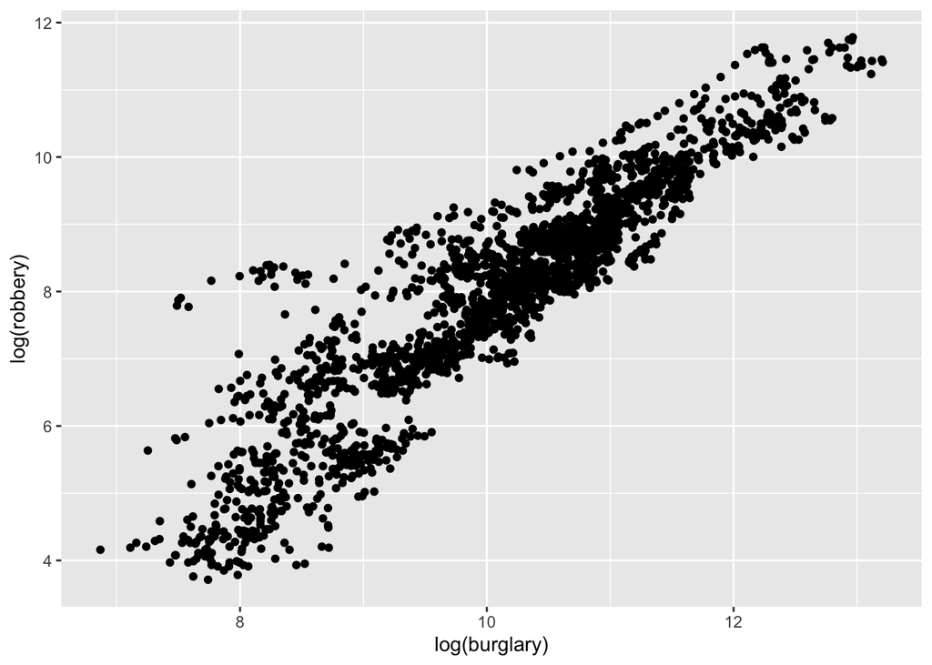

```r
library(ggplot2)

ggplot(fbiwide, aes(x = log(burglary), y = log(robbery))) + geom_point()
```

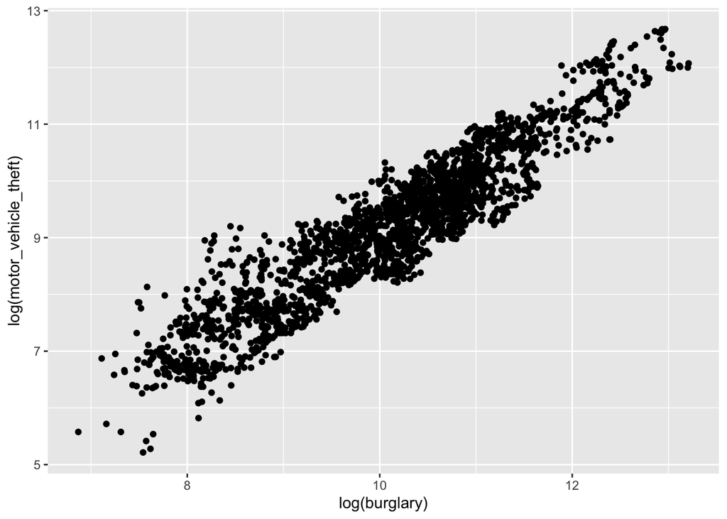

```r
ggplot(fbiwide, aes(x = log(burglary), y = log(motor_vehicle_theft))) + geom_point()
```

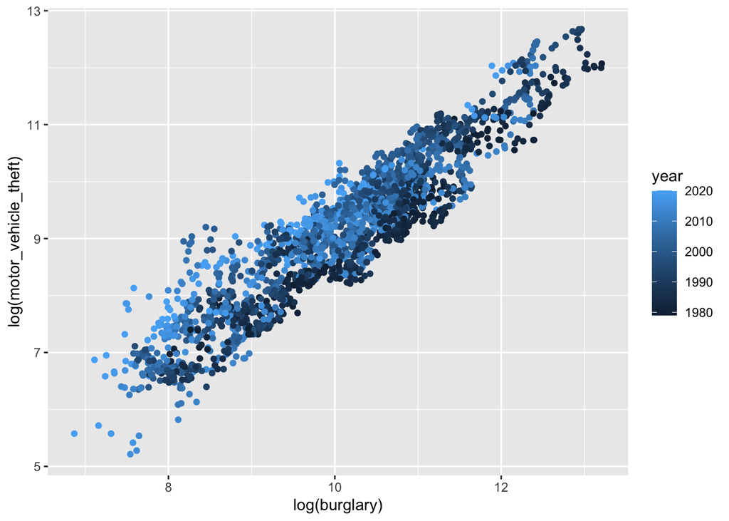

```r
# Add color by years

ggplot(fbiwide, aes(x = log(burglary), y = log(motor_vehicle_theft), colour = year)) + geom_point()
```

## Questions in the lecture “02_r-graphics”

1. Draw a scatterplot of the log transformed number of burglaries by motor vehicle thefts. Map the state variable to colour. Why is this a terrible idea?

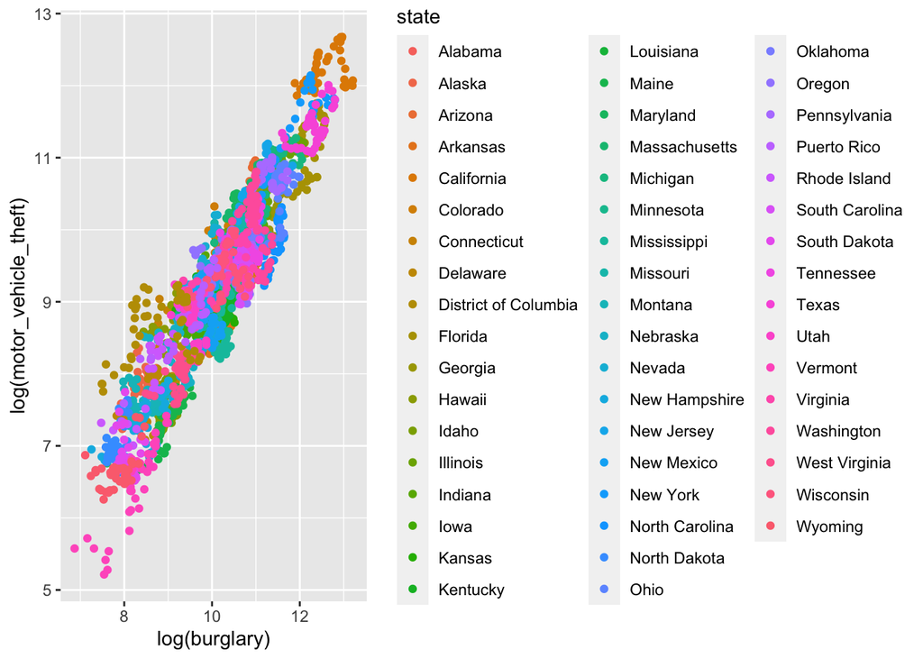

```r
ggplot(data = fbiwide, aes(x = log(burglary), y = log(motor_vehicle_theft))) + geom_point(aes(color = state))
```

This is a bad idea because too many states and colors can not separate each of them.

2. Draw a scatterplot of the log transformed number of burglaries by motor vehicle thefts. Map population to size. How do we interpret the output?

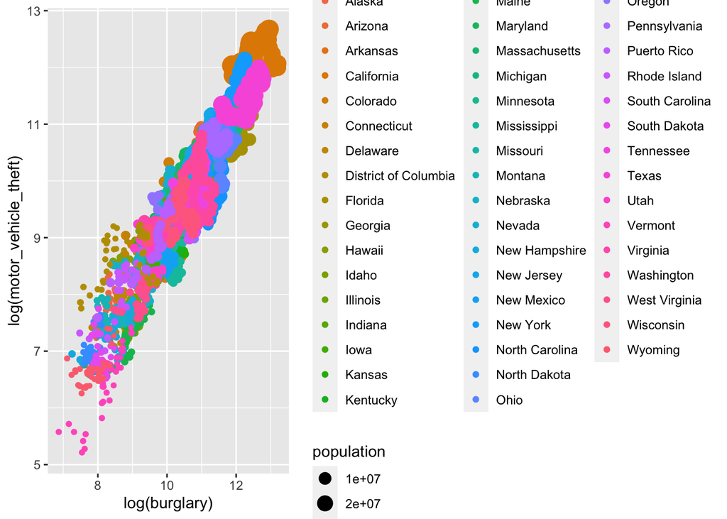

```r
ggplot(data = fbiwide, aes(x = log(burglary), y = log(motor_vehicle_theft))) + geom_point(aes(color = state, size = population))
```

3. Have a look at the RStudio cheat sheet on visualization. Draw a histogram of the state populations

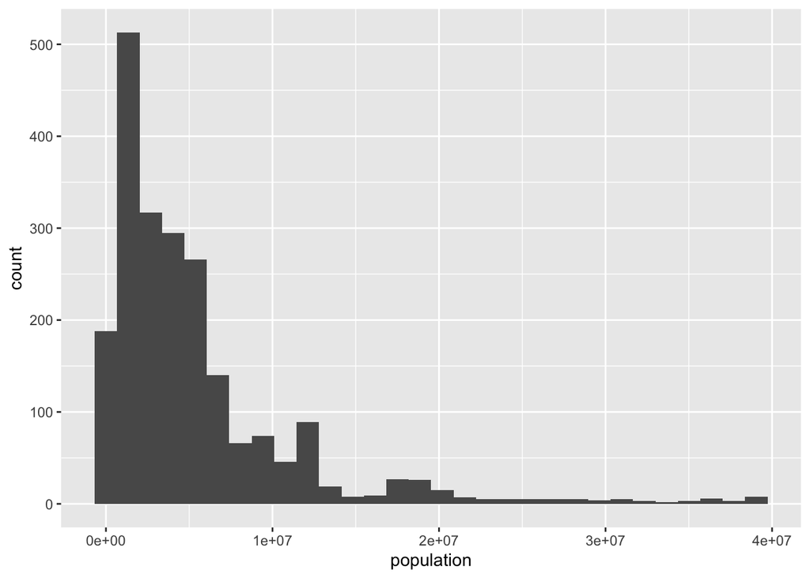

```r
ggplot(data = fbiwide, aes(x = population)) + geom_histogram()
```

The above histogram does not make sense as it includes multiple years for the same state.

We make the histogram of popualtion for 2019.

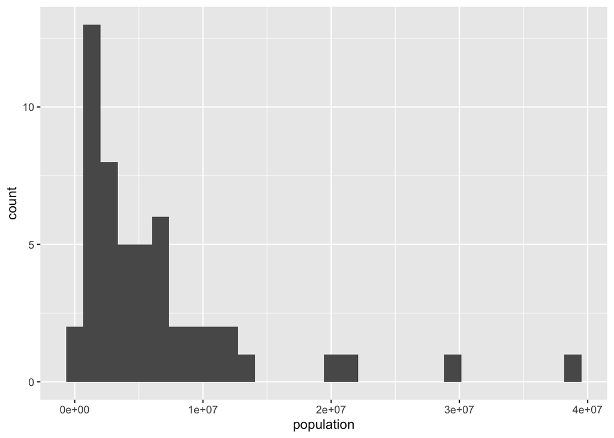

```r
ggplot(data = fbiwide[fbiwide$year == 2019, ], aes(x = population)) + geom_histogram()
```

4. Compare the log transformed number of burglaries by motor vehicle thefts over years. How to make a nice plot?

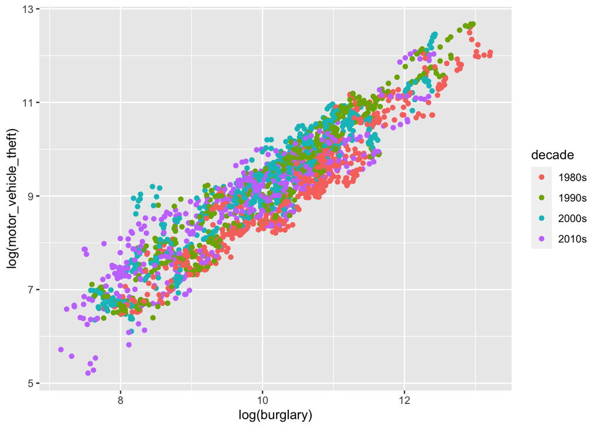

```r
fbiwide1 = fbiwide
fbiwide1 = fbiwide1[fbiwide1$year >= 1980, ]
fbiwide1 = fbiwide1[fbiwide1$year < 2020, ]
fbiwide1$decade = floor(fbiwide1$year / 10)
fbiwide1$decade = paste0(fbiwide1$decade, "0s")

ggplot(data = fbiwide1, aes(x = log(burglary), y = log(motor_vehicle_theft))) + geom_point(aes(color = decade))
```

5. Compare the log transformed number of burglaries by motor vehicle thefts over States, coloured by years.

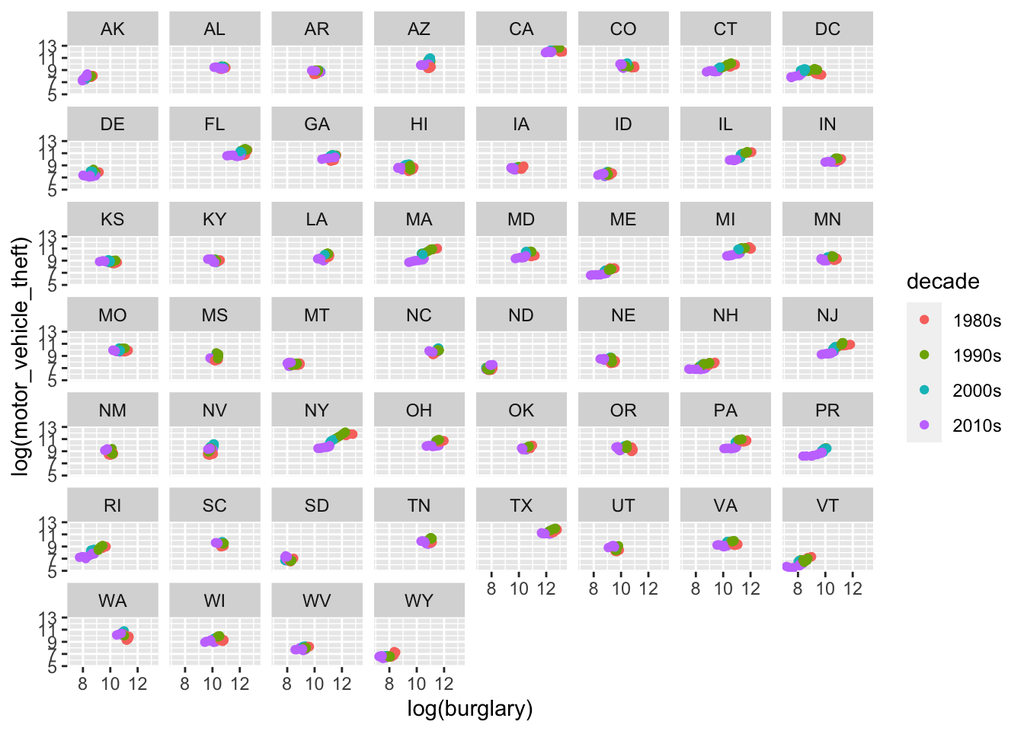

```r
ggplot(data = fbiwide1, aes(x = log(burglary), y = log(motor_vehicle_theft))) + geom_point(aes(color = decade)) + facet_wrap(.~ state_abbr)
```

6. Now, only focus on comparing California, Colorado, Iowa, Illinois, District of Columbia and New York.

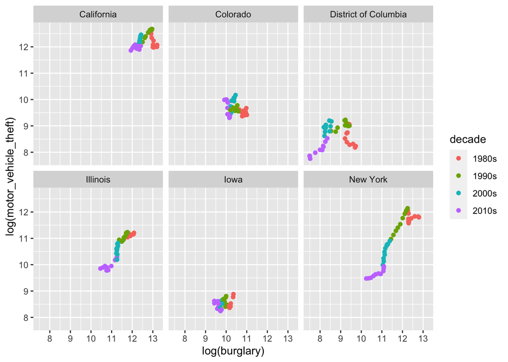

```r
state.subset = c("California", "Colorado", "Iowa", "Illinois", "District of Columbia", "New York")

fbiwide2 = fbiwide1[fbiwide1$state %in% state.subset, ]
ggplot(data = fbiwide2, aes(x = log(burglary), y = log(motor_vehicle_theft))) + geom_point(aes(color = decade)) + facet_wrap(.~ state)
```

7. We all know population is an important factor. How to compare different states by standardized population?

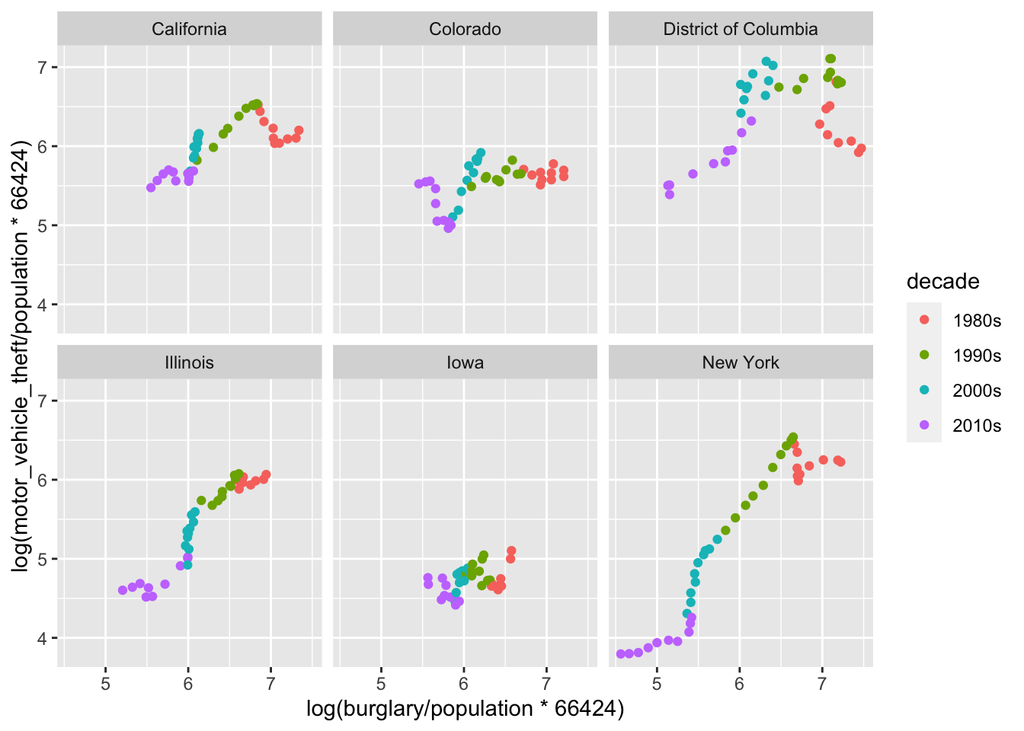

```r
ggplot(data = fbiwide2, aes(x = log(burglary / population * 66424), y = log(motor_vehicle_theft / population * 66424))) + geom_point(aes(color = decade)) + facet_wrap(.~ state)
```